# Income growth dependence

Use income growth data `sample_growth_tb` to examine dependence across periods. Select individuals using beginning-of-period income and age conditions for 2014–15, and calculate Spearman rank correlations over the six periods from 2014–15 to 2019–20. Use growth in 2014–15 and 2015–16 to calculate a tail dependence measure and the cumulative mean of growth in the following period after transforming it to nonnegative values.

## 1 Rank correlations of growth rates

```r
library(tidyverse)
library(pins)

# Specify relative paths for the board, figure output directory, and plotting theme.
board <- board_folder("../income_board_replicate")
graph_dir <- "graph"
dir.create(graph_dir, recursive = TRUE, showWarnings = FALSE)
source("theme_ipsum_like.R")
theme_set(theme_ipsum())
```

**Setting sample conditions**

```r
library(corrr)
library(scattermore)
```

Define `pobs()` to transform growth rates into rank-based pseudo-observations. Use average ranks for ties and divide by the length of the original vector plus one.

```r
pobs <- function(x) {
  rank(x, ties.method = "average", na.last = "keep") / (length(x) + 1)
}
```

Load `sample_growth_tb` and calculate age `age` as the beginning year extracted from period label `year` minus the birth year in the first four characters of `birth_date`. For 2014–15 growth records (`g_15_14`), save the `id` values of individuals with beginning-of-period income `pre_income` of at least 4 million yen and beginning-of-period age 25–60 in `id_tb`. Use this set of individuals for both rank correlations and tail analyses.

```r
sample_growth_tb <- board |> pin_read("sample_growth_tb") |>
  mutate(age = as.numeric(str_c(20, str_sub(year,6,7))) - as.numeric(str_sub(birth_date,1,4)))

id_tb <- sample_growth_tb |>
  filter(year == "g_15_14",
         pre_income >= 4*10^6,
         age >= 25, age <= 60) |>
  select(id) |>
  distinct(id)
```

**Spearman rank correlations across six periods**

Use a common sample with finite growth rates in all six periods from 2014–15 to 2019–20.

```r
growth_periods <- c(
  "g_20_19", "g_19_18", "g_18_17",
  "g_17_16", "g_16_15", "g_15_14"
)

growth_wide_tb <- sample_growth_tb |>
  filter(year %in% growth_periods) |>
  select(id, year, growth) |>
  pivot_wider(id_cols = id, names_from = year, values_from = growth) |>
  inner_join(id_tb, by = "id") |>
  select(-id) |>
  filter(if_all(everything(), is.finite))

growth_wide_tb |> correlate(method = "spearman")
```

| term | g_20_19 | g_19_18 | g_18_17 | g_17_16 | g_16_15 | g_15_14 |
| --- | --- | --- | --- | --- | --- | --- |
| g_20_19 | NA | -1.527734e-05 | 0.0004446572 | 0.0005854468 | 0.0002401249 | -0.0006580487 |
| g_19_18 | -1.527734e-05 | NA | 0.0018374908 | 0.0002270122 | -0.0006574027 | -0.0003903636 |
| g_18_17 | 4.446572e-04 | 1.837491e-03 | NA | 0.0010627830 | -0.0008408969 | 0.0001157248 |
| g_17_16 | 5.854468e-04 | 2.270122e-04 | 0.0010627830 | NA | -0.0003082363 | -0.0001789358 |
| g_16_15 | 2.401249e-04 | -6.574027e-04 | -0.0008408969 | -0.0003082363 | NA | 0.0010041351 |
| g_15_14 | -6.580487e-04 | -3.903636e-04 | 0.0001157248 | -0.0001789358 | 0.0010041351 | NA |

## 2 Dependence in the tail

**Data for the two-period tail analysis**

For the selected individuals, retain observations with finite growth rates in both 2014–15 and 2015–16 in `normal_tb`. Calculate pseudo-observations separately for these two periods.

```r
normal_tb <- sample_growth_tb |>
  pivot_wider(id_cols = id, names_from = "year", values_from = "growth") |>
  inner_join(id_tb, by = "id") |>
  select(g_16_15, g_15_14) |>
  filter(is.finite(g_16_15), is.finite(g_15_14)) |>
  mutate(pobs_16_15 = pobs(g_16_15), pobs_15_14 = pobs(g_15_14))
```

**Tail dependence measure**

Let $N_q$ be the number of observations whose pseudo-observations exceed threshold $q$ in both periods, and $N$ the analysis sample size. Calculate the tail dependence measure as $N_q/[N(1-q)]$. Vary $q$ from 0.8 to 0.9995 in increments of 0.0005.

```r
tail_tb <- seq(0.8, 0.9995, by = 0.0005) |>
  map_dfr(~ normal_tb |>
            filter(pobs_16_15 > .x, pobs_15_14 > .x) |>
            summarise(criteria = .x,
                      tail_coeff = (n()/nrow(normal_tb))/(1 - .x))
          )
```

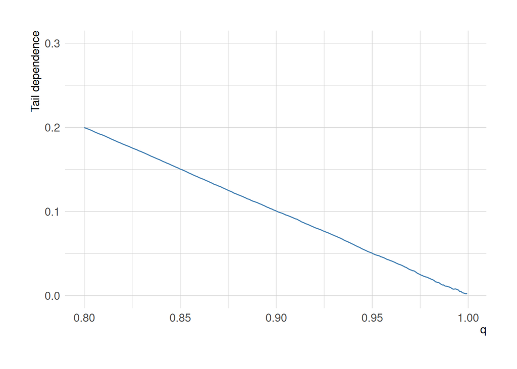

```r
tail_tb |>
ggplot(aes(criteria, tail_coeff)) +
  geom_line(color = "steelblue") +
  ylim(0, 0.3) +
  labs(x = expression(q),
       y = "Tail dependence")
ggsave(filename = "tail_coeff_income.png", path = graph_dir)
```

**Cumulative mean of nonnegative growth in the following period**

Sort individuals by descending growth in 2014–15, transform growth in the following period (2015–16) to $\max(g_{16,15}, 0)$, and calculate its cumulative mean. Use 2014–15 growth $t$ on the horizontal axis to examine average nonnegative growth in the following period among individuals who experienced large growth. Calculate using all of `normal_tb`, restricting only the displayed horizontal range to 0.2–2 and vertical range to 0–0.5.

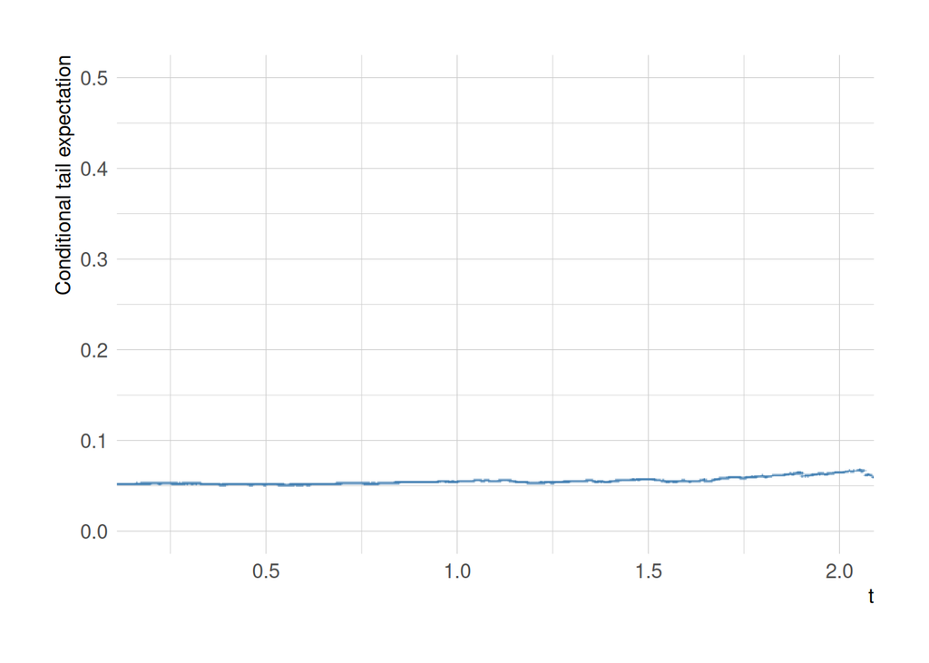

```r
normal_tb |>
  arrange(desc(g_15_14)) |>
  mutate(
    g_16_15 = if_else(g_16_15 > 0, g_16_15, 0),
    cummean_16_15 = cummean(g_16_15)
  ) |>
ggplot(aes(g_15_14, cummean_16_15)) +
  geom_scattermore(pointsize = 1.5, color = "steelblue") +
  coord_cartesian(xlim = c(0.2, 2), ylim = c(0, 0.5)) +
  labs(x = "t",
       y = "Conditional tail expectation")
ggsave(filename = "cond_tail_expect_g_15_14_transformed_income.png", path = graph_dir)
```